# 12-09-2014

# Data Roadmap: From Raw to Draw

### Todayâ€™s Goals

Preparing the workspace for statistical modeling and graphing may involve a number of steps and separate scripts.

Goals for today:  
1. Open updated version of Hypertension-and-Cognition repository  
2. Follow the path from RAW data files to DRAWing statistical graphs

## I. Open updated version

1. Open GitHub on your local machine

[figure not shown]

2. Select the repository to work with. Clone if necessary.

[figure not shown]

3. Select the branch

[figure not shown]

4. Sync (commit if necessary)

[figure not shown]

5. Open the repository in File Explorer (FE)
- (Right-click on repositoryâ€™s name in the left sidebar)

[figure not shown]

6. In FE open the `.Rpoj` file to initiate RStudio Session

[figure not shown]

   Now you should have your RStudio open in the current state of your repository

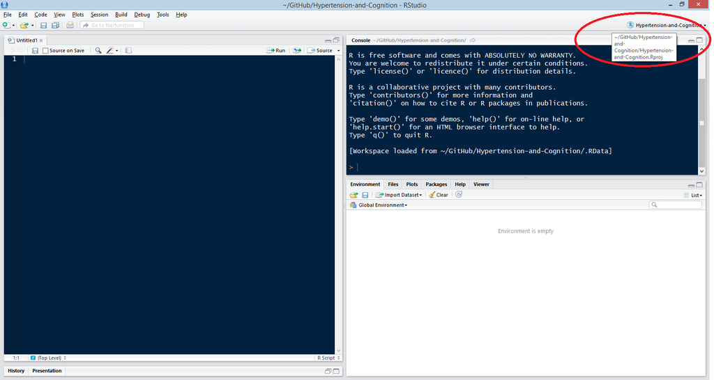

## Follow the RAW-to-DRAW path

### Data Geneology

#### Raw files

- optional stage
- as-is in the secondary source
- read-only

#### ds0

- referred to as `ds0`
- verbatim input from raw files
- minimum or no processing
- “patient zero”

#### dsL

- span of the project
- subset of ds0
- long (L) or wide (W) data formats, respectively
- provides richer context
- invites future research
- experimentation

#### dsM

- model ready
- used for estimating models and producing graphs
- subset of dsL
- usually adds custom data

#### ds

- nameless dataset
- temporary and recyclable
- used to make code exchangeable

The process can be described the following diagram:

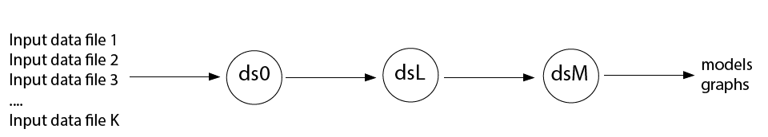